# Portfolio8-Concise Text

April 18, 2022

With Portfolio 7, I saw how to insert text within a graph. This could be useful for all sorts of reasons. The drawback with the method I used was that I had to manually insert an x & y coordinate for each text item, as well as a color and each individual text itself. Each text item requires one line of code. For this project, I want to see if there is a more concise code for doing this.

1. First, we must install packages / libraries, and a code that I need for Mac.

```r
r = getOption("repos")
r["CRAN"] = "http://cran.us.r-project.org"
options(repos = r)
```

```r
install.packages('tidyr')
install.packages('readr')
```

```r
library(ggplot2)
library(tidyr)
```

```r
install.packages("dplyr")
library(dplyr)
```

2. Next, I will read my Excel docs into a data frame:

```r
library(readr)
dfMil <-read.csv("~/Documents/GitHub/Portfolio7-VizStats2/dfMil.csv")
View(dfMil)
```

```r
MilStatsExcel <-read.csv("~/Documents/GitHub/Portfolio7-VizStats2/MilStatsExcel.csv")
View(MilStatsExcel)
```

And we’ll need ggrepel for the Text boxes.

```r
install.packages("ggrepel")
library(ggrepel)
```

3. Here is my previous example, from Portfolio 7, of what we can do with the text boxes.

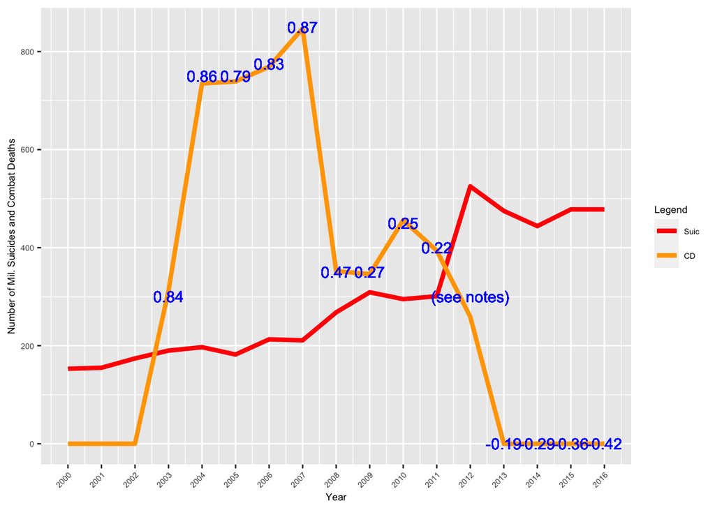

```r
colors <- c("Suic" = "red", "CD" = "orange")
ggplot(dfMil, aes(x=Time)) +
  geom_line(aes(y = Suic, color = "Suic"), size = 1.5) +
  geom_line(aes(y = CD, color="CD"), size = 1.5) +
labs(
   x = "Year",
   y = "Number of Mil. Suicides and Combat Deaths",
   color = "Legend"
 ) +
scale_color_manual(values = colors) +
  scale_x_continuous(breaks = c(2000,2001,2002,2003,2004,2005,2006,2007,2008,2009,2010,2011,2012,2013,2014,2015,2016)) +
theme(text = element_text(size=7),
        axis.text.x = element_text(angle=45, hjust=1)) +
geom_text(x=2003, y=300, label="0.84", color="blue") +
geom_text(x=2004, y=750, label="0.86", color="blue") +
  geom_text(x=2005, y=750, label="0.79", color="blue") +
geom_text(x=2006, y=775, label="0.83", color="blue") +
geom_text(x=2007, y=850, label="0.87", color="blue") +
  geom_text(x=2008, y=350, label="0.47", color="blue") +
geom_text(x=2009, y=350, label="0.27", color="blue") +
geom_text(x=2010, y=450, label="0.25", color="blue") +
  geom_text(x=2011, y=400, label="0.22", color="blue") +
  geom_text(x=2012, y=300, label="(see notes)", color="blue") +
geom_text(x=2013, y=0, label="-0.19", color="blue") +
  geom_text(x=2014, y=0, label="-0.29", color="blue") +
  geom_text(x=2015, y=0, label="-0.36", color="blue") +
  geom_text(x=2016, y=0, label="-0.42", color="blue")
```

That was close to what I’m looking for. However, the placement of the text needs a more aesthetic position that aligns with a quantitative meaning. Also, I really need more concise code for inserting multiple texts into a graph. Let’s see how we might be able to go about that.

4. Using a simple example from the RPubs website (https://rpubs.com/RatherBit/188960), I am going to mirror the example code with my own data. Here is the data example from RPubs:

```r
library(car)
data(cars)
head(cars)
```

```
##   speed dist
## 1     4    2
## 2     4   10
## 3     7    4
## 4     7   22
## 5     8   16
## 6     9   10
```

5. Let’s look at our data frames:

```r
str(cars)
```

```
## 'data.frame':    50 obs. of  2 variables:
##  $ speed: num  4 4 7 7 8 9 10 10 10 11 ...
##  $ dist : num  2 10 4 22 16 10 18 26 34 17 ...
```

```r
str(dfMil)
```

```
## 'data.frame':    17 obs. of  3 variables:
##  $ Time: int  2000 2001 2002 2003 2004 2005 2006 2007 2008 2009 ...
##  $ CD  : int  0 0 0 312 735 739 769 847 352 346 ...
##  $ Suic: int  153 155 174 190 197 182 213 211 268 309 ...
```

6. Next, we’ll summarize the model

```r
mod <- lm(dist ~speed, data=cars)
summary(mod)
```

```
##
## Call:
## lm(formula = dist ~ speed, data = cars)
##
## Residuals:
##     Min      1Q  Median      3Q     Max
## -29.069  -9.525  -2.272   9.215  43.201
##
## Coefficients:
##             Estimate Std. Error t value Pr(>|t|)
## (Intercept) -17.5791     6.7584  -2.601   0.0123 *
## speed         3.9324     0.4155   9.464 1.49e-12 ***
## ---
## Signif. codes:  0 '***' 0.001 '**' 0.01 '*' 0.05 '.' 0.1 ' ' 1
##
## Residual standard error: 15.38 on 48 degrees of freedom
## Multiple R-squared:  0.6511, Adjusted R-squared:  0.6438
## F-statistic: 89.57 on 1 and 48 DF,  p-value: 1.49e-12
```

```r
mod_dfMil <- lm(Suic ~Time, data=dfMil)
summary(mod_dfMil)
```

```
##
## Call:
## lm(formula = Suic ~ Time, data = dfMil)
##
## Residuals:
##    Min     1Q Median     3Q    Max
## -68.27 -35.72  -3.50  21.72 131.62
##
## Coefficients:
##              Estimate Std. Error t value Pr(>|t|)
## (Intercept) -48116.53    5119.81  -9.398 1.12e-07 ***
## Time            24.11       2.55   9.456 1.04e-07 ***
## ---
## Signif. codes:  0 '***' 0.001 '**' 0.01 '*' 0.05 '.' 0.1 ' ' 1
##
## Residual standard error: 51.5 on 15 degrees of freedom
## Multiple R-squared:  0.8563, Adjusted R-squared:  0.8468
## F-statistic: 89.42 on 1 and 15 DF,  p-value: 1.038e-07
```

7. Now, we’ll add labels to points using rownames.

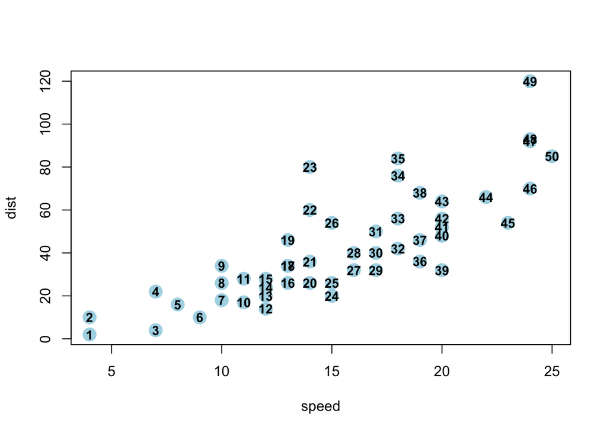

```r
plot(dist ~speed, col="lightblue", pch=19, cex=2,data=cars)
# this will add labels to points using rownames:
text(dist ~speed, labels=rownames(cars),data=cars, cex=0.9, font=2)
```

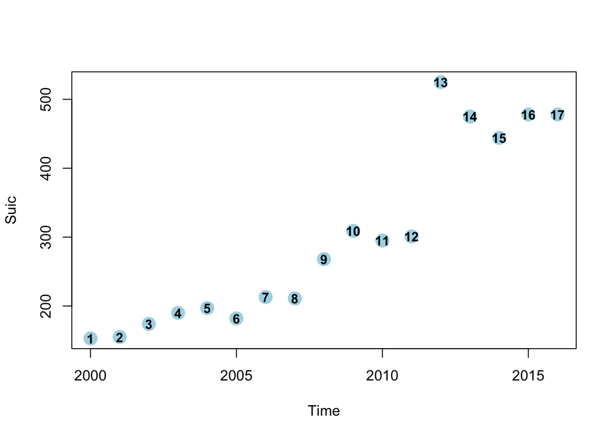

```r
plot(Suic ~Time, col="lightblue", pch=19, cex=2,data=dfMil)
text(Suic ~Time, labels=rownames(dfMil),data=dfMil, cex=0.9, font=2)
```

This code is just fine when we already have a row name built in to our data frame. Most of the time, I don’t know whether we can count on that. Clearly we need labels that illustrate something of interest to our data, when we do not have a row name. The following code allows us to use the data from ANY ROW in our data frame as the label for each individual data point.

8. Label using existing column from data frame.

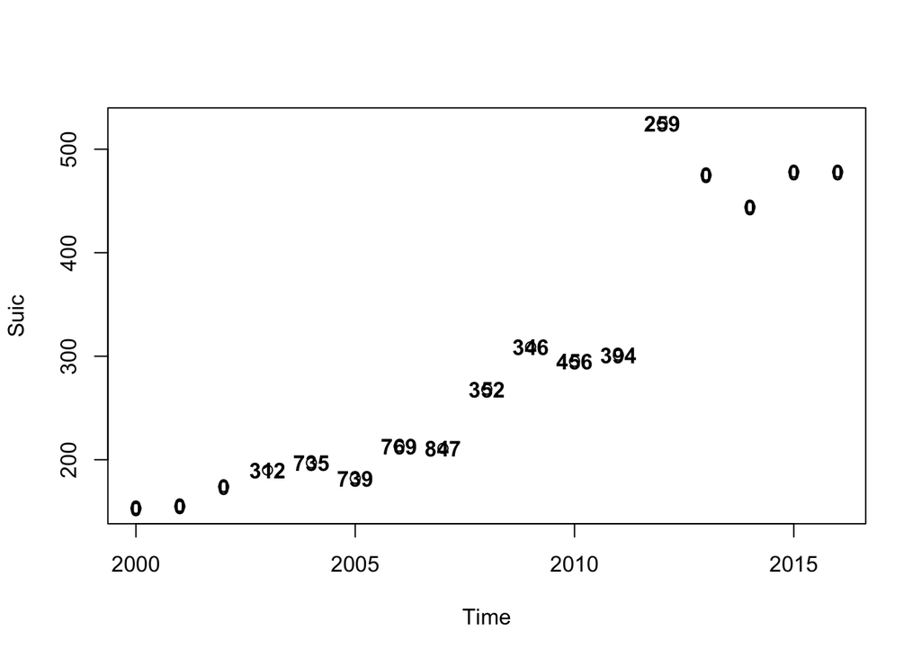

```r
plot(Suic ~Time,data=dfMil)
text(Suic ~Time, labels=CD,data=dfMil, font=2)
```

At this point, it is clear that the text labels will only be limited by our imagination, and whatever characters we can fit into a data frame!

Let’s return to my graph from Portfolio 7. I wanted to insert text at each year, showing the correlation between two variables. I’m simply going to plug the correlations for each year into the data frame and create a new column named “Pvalue”, then add those P values as labels.

Do do this, we can use this easy to follow code, from a site with way too many ads: https://r-lang.com/how-to-add-column-to-r-data-frame/

9. We can copy and paste values into our line of code. Make sure that the number of rows in our data frame (17) are equal to the length of our vector. The only drawback here is that I have to add a comma to each value, which could be time-consuming for large data sets. Of course, there is almost certainly code that automatically adds commas, but for now we’ll just go manual.

```r
NewColumn <- c(0,0,0,0.84,0.86,0.79,0.83,0.87,0.47,0.27,0.25,0.22,0.00E+00,-0.19,-0.29,-0.36,-0.42)
```

Add this new column to our dfMil data frame, and name it “PValue”.

```r
dfMil$Pvalue <- NewColumn
cat("After adding a new column", "\n")
```

```
## After adding a new column
```

```r
dfMil
```

```
##    Time  CD Suic Pvalue
## 1  2000   0  153   0.00
## 2  2001   0  155   0.00
## 3  2002   0  174   0.00
## 4  2003 312  190   0.84
## 5  2004 735  197   0.86
## 6  2005 739  182   0.79
## 7  2006 769  213   0.83
## 8  2007 847  211   0.87
## 9  2008 352  268   0.47
## 10 2009 346  309   0.27
## 11 2010 456  295   0.25
## 12 2011 394  301   0.22
## 13 2012 259  525   0.00
## 14 2013   0  475  -0.19
## 15 2014   0  444  -0.29
## 16 2015   0  478  -0.36
## 17 2016   0  478  -0.42
```

There is our new column “Pvalue”

10. The P values can now be inserted directly into a graph using a concise line of code!

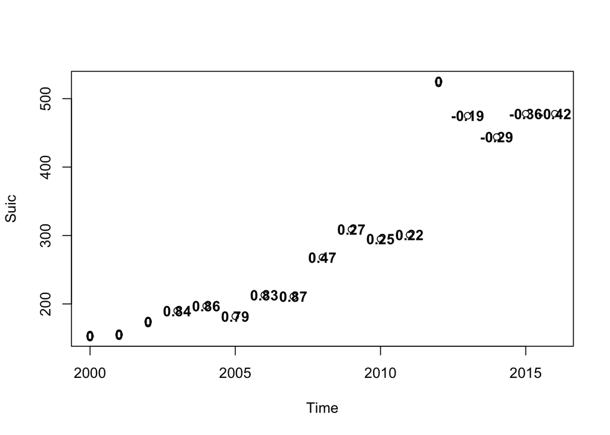

```r
plot(Suic ~Time,data=dfMil)
text(Suic ~Time, labels=Pvalue,data=dfMil, font=2)
```

This is close to what I had in mind, but we’ve lost the detail of my previous graph. In any event, we can add more individualized text for specific labels.

```r
NewColumnChar <- c("P Value 2000",0,0,0.84,0.86,0.79,0.83,0.87,0.47,0.27,0.25,0.22,0.00E+00,-0.19,-0.29,-0.36,-0.42)
```

```r
dfMil$PvalueChar <- NewColumnChar
```

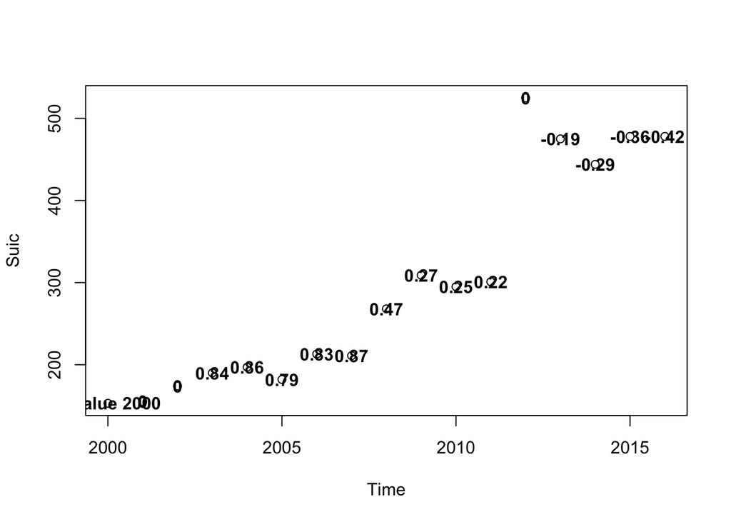

```r
plot(Suic ~Time,data=dfMil)
text(Suic ~Time, labels=PvalueChar,data=dfMil, font=2)
```

On the plus side, I’ve found a way to insert labels from a column in my data frame, using concise code. On the con side, I’m now dealing with an extremely rudimentary graph; all of the refinement of my graph at step #3 is now absent from this code. I’ll need to find a way to re-incorporate my labels into my preferred graphing code, from step #3. Nonetheless, I am glad that such concise code is available, and this can be built upon!